# Exploring metrics for evaluating and comparing models

Matthew Van Hala

April 21, 2022

```r
library(dplyr)
library(ggplot2)
set.seed(427)
```

# 1 Introduction

In fitting models, there are a number of different metrics one can try to optimize (e.g., log likelihood, root mean squared error, mean absolute percent error).

In this notebook we will look at three metrics for evaluating and comparing models. Our focus will be on regression problems, particularly heavily skewed insurance pricing data. Classification problems have commonly used metrics (e.g., precision, recall, F-score, ROC curve) which are intuitive.

We will focus on metrics with a flavor of intuitive application to the insurance model context, in comparison to some of the classic or standard metrics.

In particular, we will examine three different metrics:

1. Area under a Lorenz curve as a measure of directional segmentation
2. Cramer-von Mises distance between the distributions of actual and predicted loss as a measure of quantitative model calibration
3. Weighted variance of predictions as a measure of the degree of segmentation

Each of these metrics has their advantages and disadvantages. In this notebook, we try to explain how they are calculated, what they are useful for, and their limitations.

# 2 Simulated data

## 2.1 Example 1

Let’s consider the following. We’ll simulate loss data for 1,000,000 policies, where losses are simulated from a Tweedie distribution in which the mean varies based on one attribute.

```r
n <- 1000000

data_sim_1 <- tibble(
  id = 1:n,
  x1 = rnorm(n),
  x2 = rnorm(n),
  loss = tweedie::rtweedie(n, p = 1.33, phi = 650, mu = exp(5 + 0.5 * x1)),
  weight = 1
)
```

We’ll fit a GLM to the simulated data.

```r
fitted_model_1 <- glm(
  loss ~ x1,
  data = data_sim_1,
  family = statmod::tweedie(var.power = 1.5, link.power = 0),
  model = FALSE,
  y = FALSE
)
```

Here are the estimated parameters from the fitted model. The true parameter values are 5 for the intercept and 0.5 for `x1`.

```r
coef(fitted_model_1)
```

```
## (Intercept)          x1
##   4.9908073   0.5037692
```

Let’s get the predicted values on the simulated data set.

```r
data_sim_pred_1 <- data_sim_1 %>%
  mutate(
    predict = exp(coef(fitted_model_1)[1] + coef(fitted_model_1)[2] * x1)
  )
```

## 2.2 Example 2

We’ll simulate another data set, this time for 50,000 policies. As before, we’ll fit a GLM and get predicted values.

```r
n <- 50000

data_sim_2 <- tibble(
  id = 1:n,
  x1 = rnorm(n),
  loss = tweedie::rtweedie(n, p = 1.33, phi = 650, mu = exp(0.2 + 0.5 * x1)),
  weight = 1
)

fitted_model_2 <- glm(
  loss ~ x1,
  data = data_sim_2,
  family = statmod::tweedie(var.power = 1.5, link.power = 0),
  model = FALSE,
  y = FALSE
)

data_sim_pred_2 <- data_sim_2 %>%
  mutate(
    predict = exp(coef(fitted_model_2)[1] + coef(fitted_model_2)[2] * x1)
  )
```

# 3 Lorenz curve

The Lorenz curve is useful as a measure of the quality of directional segmentation created by a model.

To compute a Lorenz curve, we do the following.

1. Get the predicted values for all observations.
2. Sort observations by predicted in decreasing order.
3. Calculate two new columns: a column with the cumulative percentage of exposure, and a column with the cumulative percentage of actual loss.

Here is some sample code for computing a Lorenz curve.

```r
calc_lorenz_curve <- function(data, pred_col, tgt_x_wgt_col, wgt_col) {
  pred_col <- sym(pred_col)
  tgt_x_wgt_col <- sym(tgt_x_wgt_col)
  wgt_col <- sym(wgt_col)

  by_pred <- data %>%
    dtplyr::lazy_dt() %>%
    group_by(!!pred_col) %>%
    summarise(.wgt = sum(!!wgt_col), .tgt_x_wgt = sum(!!tgt_x_wgt_col)) %>%
    arrange(desc(!!pred_col)) %>%
    mutate(
      cum_pct_wgt = cumsum(.wgt) / sum(.wgt),
      cum_pct_tgt = cumsum(.tgt_x_wgt) / sum(.tgt_x_wgt)
    ) %>%
    select(cum_pct_wgt, cum_pct_tgt) %>%
    data.table::as.data.table()

  initial_row <- data.table::data.table(cum_pct_wgt = 0, cum_pct_tgt = 0)

  dplyr::bind_rows(initial_row, by_pred)
}
```

Let’s calculate the Lorenz curve for the first sample simulated model fit above.

```r
sim_lorenz_curve <- calc_lorenz_curve(
  data_sim_pred_1,
  "predict",
  "loss",
  "weight"
)
```

Let’s look at a few sample rows.

```r
sim_lorenz_curve %>%
  as_tibble() %>%
  slice(
    c(1:3,
      round(seq(1000, n() - 1000, length.out = 20)),
      (n() - 2):n()
    )
  ) %>%
  print(n = Inf)
```

```
## # A tibble: 26 x 2
##    cum_pct_wgt cum_pct_tgt
##          <dbl>       <dbl>
##  1    0          0
##  2    0.000001   0.0000247
##  3    0.000002   0.0000247
##  4    0.000999   0.00457
##  5    0.0535     0.135
##  6    0.106      0.230
##  7    0.159      0.311
##  8    0.211      0.383
##  9    0.264      0.449
## 10    0.316      0.511
## 11    0.369      0.568
## 12    0.421      0.619
## 13    0.474      0.669
## 14    0.526      0.714
## 15    0.579      0.758
## 16    0.631      0.799
## 17    0.684      0.837
## 18    0.736      0.873
## 19    0.789      0.904
## 20    0.841      0.933
## 21    0.894      0.960
## 22    0.946      0.983
## 23    0.999      1.00
## 24    1.00       1
## 25    1.00       1
## 26    1          1
```

## 3.1 Plotting Lorenz curves

In plotting a Lorenz curve, we plot the cumulative percentage of exposure on the x-axis and the cumulative percentage of loss on the y-axis.

The following function will help us plot Lorenz curves.

```r
plot_dist_curve <- function(curve,
                            tgt_col,
                            wgt_col,
                            grp_col = NULL,
                            title = NULL) {
  curve <- curve %>%
    as_tibble() %>%
    group_by_at(grp_col) %>%
    filter(
      !!sym(tgt_col) != lag(!!sym(tgt_col), default = -Inf) |
        !!sym(tgt_col) != lead(!!sym(tgt_col), default = Inf)
    ) %>%
    ungroup()

  plot <- ggplot2::ggplot() +
    ggplot2::theme_minimal()

  if (!is.null(grp_col)) {
    plot <- plot +
      ggplot2::geom_segment(
        ggplot2::aes(x = 0, y = 0, xend = 1, yend = 1),
        color = "black",
        size = 1.2
      ) +
      ggplot2::geom_line(
        data = curve,
        aes(x = !!sym(wgt_col), y = !!sym(tgt_col), color = !!sym(grp_col)),
        size = 1.2
      ) +
      scale_color_manual(values = pals::glasbey(length(unique(curve[[grp_col]]))))
  } else {
    plot <- plot +
      ggplot2::geom_segment(
        ggplot2::aes(x = 0, y = 0, xend = 1, yend = 1),
        color = "red",
        size = 1.2
      ) +
      ggplot2::geom_line(
        data = curve,
        aes(x = !!sym(wgt_col), y = !!sym(tgt_col)),
        size = 1.2
      )

  }

  plot +
    ggplot2::theme(
      legend.title = ggplot2::element_blank()
    ) +
    ggplot2::ggtitle(title)
}
```

Here is a Lorenz for the sample simulated model fit above. The black curve is the Lorenz curve and the red line is the 45-degree line of equality. A model with no predictive power will have a Lorenz curve that bounces around the line of equality.

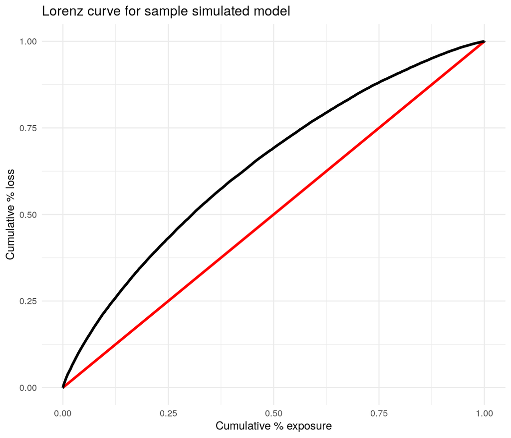

```r
plot_dist_curve(
  sim_lorenz_curve,
  tgt_col = "cum_pct_tgt",
  wgt_col = "cum_pct_wgt",
  title = "Lorenz curve for sample simulated model"
) +
  xlab("Cumulative % exposure") +
  ylab("Cumulative % loss")
```

The better the model the predicts, the faster the curve will rise. In the case of perfect segmentation, the curve would shoot up straight to 1 as rapidly as possible.

Let’s compare three sample Lorenz curves. In this, the curve for Model 2 is always above Model 1, so Model 2 dominates Model 1 with respect to directional segmentation. Model 3 neither universally dominates nor is dominated by Models 1 and 2, as there are points at which Model 3 is above the curves for Models 1 and 2 along with points at which Model 3 is below the curves for Models 1 and 2.

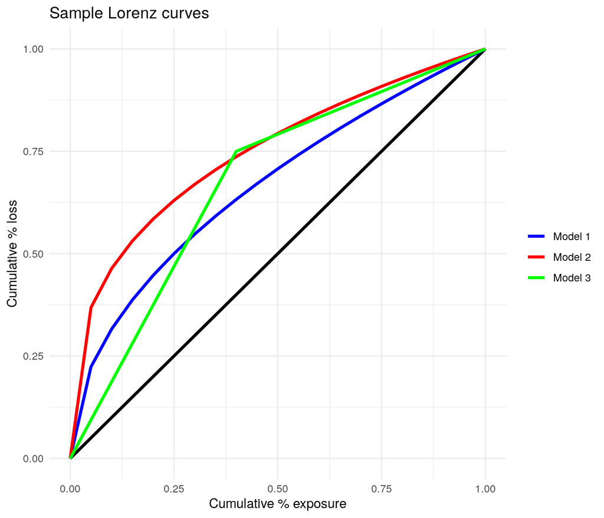

```r
sample_lorenz_compare <- tibble(
  pct_expo = seq(0, 1, by = 0.05),
  `Model 1` = (pct_expo) ^ (1/ 2),
  `Model 2` = (pct_expo) ^ (1/ 3),
  `Model 3` = .75 / .4 * pmin(pct_expo, 0.4) + .25 / .6 * pmax(0, pct_expo - 0.4)
)

plot_dist_curve(
  sample_lorenz_compare %>%
    tidyr::pivot_longer(
      c(starts_with("Model")),
      names_to = "grp",
      values_to = "pct_tgt"
    ),
  tgt_col = "pct_tgt",
  wgt_col = "pct_expo",
  grp_col = "grp",
  title = "Sample Lorenz curves"
) +
  xlab("Cumulative % exposure") +
  ylab("Cumulative % loss")
```

## 3.2 Summarizing a Lorenz curve: area under the curve

A model providing better segmentation is characterized by having a higher and more steeply rising Lorenz curve. If you have two Lorenz curves and one curve is greater than or equal to the other at all points, then that higher one dominates the other.

We can summarize a Lorenz curve into a scalar metric, namely, the area under the curve. The greater the area under the Lorenz curve, the better the model segmentation.

The following function will compute the area under a Lorenz curve using the trapezoidal method for numerical integration.

```r
calc_lorenz_auc <- function(curve, tgt_col = "cum_pct_tgt", wgt_col = "cum_pct_wgt") {
  tgt_col <- sym(tgt_col)
  wgt_col <- sym(wgt_col)
  curve %>%
    dtplyr::lazy_dt() %>%
    dplyr::mutate(
      xdiff = !!wgt_col - dplyr::lag(!!wgt_col, default = 0),
      area = xdiff * (!!tgt_col + dplyr::lag(!!tgt_col, default = 0))/2
    ) %>%
    summarise(auc = sum(area)) %>%
    as_tibble() %>%
    pull(auc)
}
```

Here we invoke this function to compute the area under the Lorenz curve for the sample simulated model.

```r
calc_lorenz_auc(sim_lorenz_curve)
```

```
## [1] 0.6393225
```

```r
calc_lorenz_auc(sample_lorenz_compare, "Model 1", "pct_expo")
```

```
## [1] 0.6644466
```

```r
calc_lorenz_auc(sample_lorenz_compare, "Model 2", "pct_expo")
```

```
## [1] 0.7449607
```

```r
calc_lorenz_auc(sample_lorenz_compare, "Model 3", "pct_expo")
```

```
## [1] 0.675
```

## 3.3 Note about definitions

Lorenz curves are often calculated by sorting predicted values in increasing order. In that case, one would desire the curve the stay as low as possible until the end, when it would rapidly rise to 1. The Gini coefficient is typically defined as twice the area between the Lorenz curve and the 45-degree line of equality.

## 3.4 Limitations to Lorenz curves

The primary limitation to Lorenz curves is that they only measure the rank-order quality of segmentation.

Lorenz curves are invariant to monotonic transformations of the predicted values. If two sets of predictions have the same rank ordering of values, they will have identical Lorenz curves.

Consider the following simple example of ten observations. There are three different models with predicted losses.

```r
simple_example <- tribble(
  ~predict_1, ~predict_2, ~predict_3, ~actual_loss,
  2500,       150,        100,        100,
  2600,       350,        200,        400,
  2700,       1000,       300,        1200,
  2800,       1100,       400,        800,
  2900,       1550,       500,        1500,
  3000,       2100,       600,        2000,
  3100,       3700,       700,        4300,
  3200,       4000,       800,        3000,
  3300,       6000,       8000,       6200,
  3400,       9500,       18000,      9600
) %>%
  mutate(weight = 1)

simple_example
```

```
## # A tibble: 10 x 5
##    predict_1 predict_2 predict_3 actual_loss weight
##        <dbl>     <dbl>     <dbl>       <dbl>  <dbl>
##  1      2500       150       100         100      1
##  2      2600       350       200         400      1
##  3      2700      1000       300        1200      1
##  4      2800      1100       400         800      1
##  5      2900      1550       500        1500      1
##  6      3000      2100       600        2000      1
##  7      3100      3700       700        4300      1
##  8      3200      4000       800        3000      1
##  9      3300      6000      8000        6200      1
## 10      3400      9500     18000        9600      1
```

Each of the three sets of predicted values have the same rank ordering of predicted values, and therefore have the same Lorenz curves.

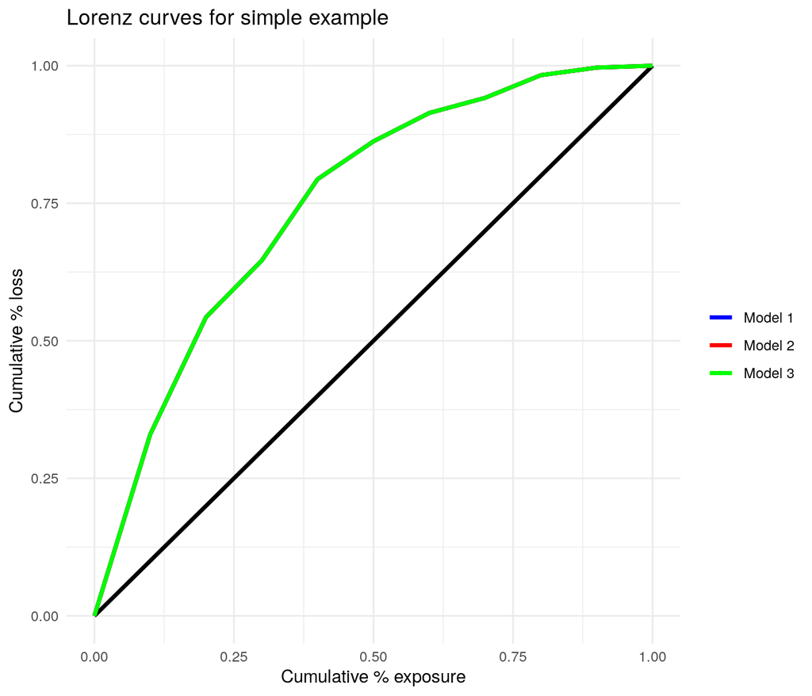

```r
simple_lorenz_1 <- calc_lorenz_curve(simple_example, "predict_1", "actual_loss", "weight")
simple_lorenz_2 <- calc_lorenz_curve(simple_example, "predict_2", "actual_loss", "weight")
simple_lorenz_3 <- calc_lorenz_curve(simple_example, "predict_3", "actual_loss", "weight")

simple_lorenz <- bind_rows(
  simple_lorenz_1 %>%
    as_tibble() %>%
    mutate(model = "Model 1"),
  simple_lorenz_2 %>%
    as_tibble() %>%
    mutate(model = "Model 2"),
  simple_lorenz_3 %>%
    as_tibble() %>%
    mutate(model = "Model 3")
)

plot_dist_curve(
  simple_lorenz,
  "cum_pct_tgt",
  "cum_pct_wgt",
  "model",
  title = "Lorenz curves for simple example"
) +
  xlab("Cumulative % exposure") +
  ylab("Cumulative % loss")
```

However, let’s plot the numeric values themselves for the predicted and actual losses of these observations.

We see that Models 1 and 3 do not fit the distribution of actual losses well.

Model 1 has too flat of a slope. It overpredicts for the lower observations and underpredicts the higher observations. Model 3 is too steep. It underpredicts the lower observations and overpredicts the higher observations. By contrast, Model 2 fits much better. The actual and predicted values are in much closer agreement.

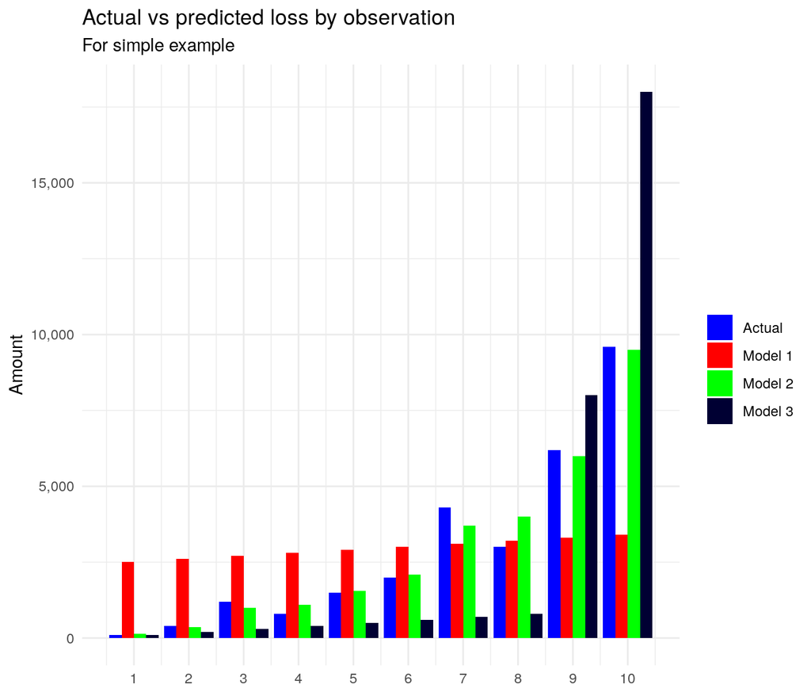

```r
ggplot(
  data = simple_example %>%
    rename(
      `Model 1` = predict_1,
      `Model 2` = predict_2,
      `Model 3` = predict_3,
      Actual = actual_loss
    ) %>%
    mutate(obs_num = 1:n()) %>%
    tidyr::pivot_longer(
      c(starts_with("Model"), Actual),
      names_to = "model",
      values_to = "amount"
    )
) +
  theme_minimal() +
  geom_bar(
    aes(x = obs_num, y = amount, fill = model),
    stat = "identity",
    position = "dodge"
  ) +
  theme(legend.title = element_blank()) +
  scale_y_continuous("Amount", labels = scales::comma) +
  scale_x_continuous(NULL, breaks = 1:10) +
  scale_fill_manual(values = pals::glasbey(4)) +
  ggtitle(
    "Actual vs predicted loss by observation",
    subtitle = "For simple example"
  )
```

Thus, even though all three models had the exact same Lorenz curves, since they had the same rank ordering of predicted values, there were major differences in how well the predicted distribution of losses matched the actual distribution of losses.

# 4 Distance between predicted and actual distributions

The limitation in Lorenz curves motivates our next metric for comparing the performance of a model.

This metric is the distance between the predicted and actual distributions of losses.

The distribution distance is useful as a measure how well-calibrated the predicted distribution is to the actual distribution.

To compute a distribution comparison curve, we do the following.

1. Get the predicted values for all observations.
2. Sort observations by predicted value in ascending order.
3. Calculate two new columns: a column with the cumulative percentage of predict loss, and a column with the cumulative percentage of actual loss.

The idea behind the distribution comparison curve is that if our model predicts $x\%$ of the total predicted loss to occur in a subset of observations, we would want $x\%$ of the total actual loss to occur within that subset of observations.

Here is some sample code for computing a distribution comparison curve.

```r
calc_prem_dist_curve <- function(data, pred_col, tgt_col, wgt_col) {
  initial_row <- data.table::data.table(cum_pct_pred = 0, cum_pct_tgt = 0)

  curve <- data %>%
    as_tibble() %>%
    select(tgt = !!sym(tgt_col), pred = !!sym(pred_col), wgt = !!sym(wgt_col)) %>%
    arrange(pred) %>%
    transmute(
      cum_pct_pred = cumsum(wgt * pred) / sum(wgt * pred),
      cum_pct_tgt = cumsum(tgt) / sum(tgt)
    )
  bind_rows(initial_row, curve)
}
```

Let’s calculate the distribution comparison curve for the second sample simulated model above.

```r
sim_dist_curve <- calc_prem_dist_curve(
  data_sim_pred_2,
  "predict",
  "loss",
  "weight"
)
```

Let’s look at a few sample rows.

```r
sim_dist_curve %>%
  as_tibble() %>%
  slice(
    c(1:3,
      round(seq(1000, n() - 1000, length.out = 20)),
      (n() - 2):n()
    )
  ) %>%
  mutate_all(~round(., 6)) %>%
  print(n = Inf)
```

```
## # A tibble: 26 x 2
##    cum_pct_pred cum_pct_tgt
##           <dbl>       <dbl>
##  1     0            0
##  2     0.000001     0
##  3     0.000002     0
##  4     0.00314      0
##  5     0.0157       0.00187
##  6     0.0322       0.00963
##  7     0.0518       0.0713
##  8     0.0742       0.0993
##  9     0.0993       0.144
## 10     0.127        0.162
## 11     0.158        0.193
## 12     0.191        0.214
## 13     0.228        0.235
## 14     0.268        0.275
## 15     0.312        0.321
## 16     0.359        0.390
## 17     0.412        0.454
## 18     0.469        0.497
## 19     0.532        0.536
## 20     0.604        0.609
## 21     0.686        0.647
## 22     0.785        0.746
## 23     0.915        0.885
## 24     1.00         1
## 25     1.00         1
## 26     1            1
```

## 4.1 Plotting distribution comparison curves

In plotting a Lorenz curve, we plot the cumulative percentage of exposure on the x-axis and the cumulative percentage of loss on the y-axis.

The function we saw above for plotting Lorenz curves can also be used for plotting distribution comparison curves.

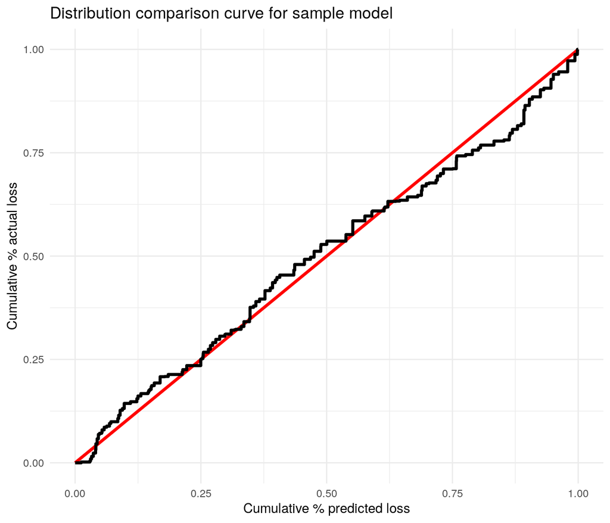

```r
plot_dist_curve(
  sim_dist_curve,
  tgt_col = "cum_pct_tgt",
  wgt_col = "cum_pct_pred",
  title = "Distribution comparison curve for sample model"
) +
  xlab("Cumulative % predicted loss") +
  ylab("Cumulative % actual loss")
```

The black line is the line of actual vs. predicted cumulative loss. The red 45-degree line is the line where the cumulative percentages of actual and predicted loss are equal.

Points on the graph can be read off in the following way. If there is a point at (25%, 30%), that means if you take the observations comprising 25% of total predicted loss (starting with the smallest predicted loss and summing up), those observations have a total of 30% of the total actual loss.

## 4.2 Summarizing a distribution comparison curve: Cramer-von Mises distance

If the distribution of predicted loss is calibrated well to the distribution of actual loss, we would see the curve of actual vs. predicted loss be close to the 45-degree line. Larger departures from the line of equality indicate poorer fits between the predicted and actual distributions.

To summarize how well the predicted distribution fits the actual distribution into a scalar metric/statistic, we call to mind measures of the distance between two distribution functions.

One of these is the Cramer-von Mises criterion, which is the integral of the square of the difference between the two distribution functions.

Other common measures of distance between distributions are:

- Anderson-Darling: a generalized version of the Cramer-von Mises statistic, where there is a weighting function that can vary over the distribution. The Cramer-von Mises statistic is Anderson-Darling where the weight is constant.
- Kolmogorov-Smirnov: the maximum distance between the two distribution functions
- Wasserstein distance: the integral of the absolute value of the difference between the distribution functions
- Kuiper distance: the sum of absolute values of the maximum positive distance between the distribution functions and the maximum negative distance between the distribution functions (i.e., $\max\left(F_1(x)-F_2(x)\right)+\max\left(F_2(x) -F_1(x) \right)$).

The following function will compute the Cramer-von Mises distance for a distribution comparison curve.

```r
calc_prem_cvm <- function(curve, pred_col = "cum_pct_pred", tgt_col = "cum_pct_tgt") {
  pred_col <- sym(pred_col)
  tgt_col <- sym(tgt_col)
  curve %>%
    as_tibble() %>%
    mutate(
      xdiff = !!pred_col - dplyr::lag(!!pred_col, default = 0),
      value = (!!tgt_col + dplyr::lag(!!tgt_col, default = 0)) / 2,
      sq_diff = (!!pred_col - value) ^ 2
    ) %>%
    summarise(distance = sum(xdiff * sq_diff)) %>%
    pull(distance)
}
```

Here we calculate the Cramer-von Mises distance between the predicted and actual loss distributions for the simulated model example.

```r
calc_prem_cvm(sim_dist_curve)
```

```
## [1] 0.0009361373
```

## 4.3 Comparative example

Let’s consider the following. We’ll use the data from the first simulated example.

Now let’s consider three different sets of predictions. The first will be the those from the fitted model. The second will have the true intercept but a coefficient of `x1` that is too small, and the third will have a coefficient of `x1` that is too large.

```r
data_sim_pred_compare <- data_sim_1 %>%
  mutate(
    predict_1 = exp(coef(fitted_model_1)[1] + coef(fitted_model_1)[2] * x1),
    predict_2 = exp(5 + 0.05 * x1),
    predict_3 = exp(5 + x1)
  )
```

First let’s compare the predicted and actual values across a range of `x1` from -2 to 2, where the bulk of the distribution lies.

We see that Model 1 is very close to the actual values, while Model 2 has a slope that is too flat (overpredicting for low `x1` and underpredicting for high `x1`), and Model 3 has a slope that is too steep (underpredicting for low `x1` and overpredicting for high `x1`).

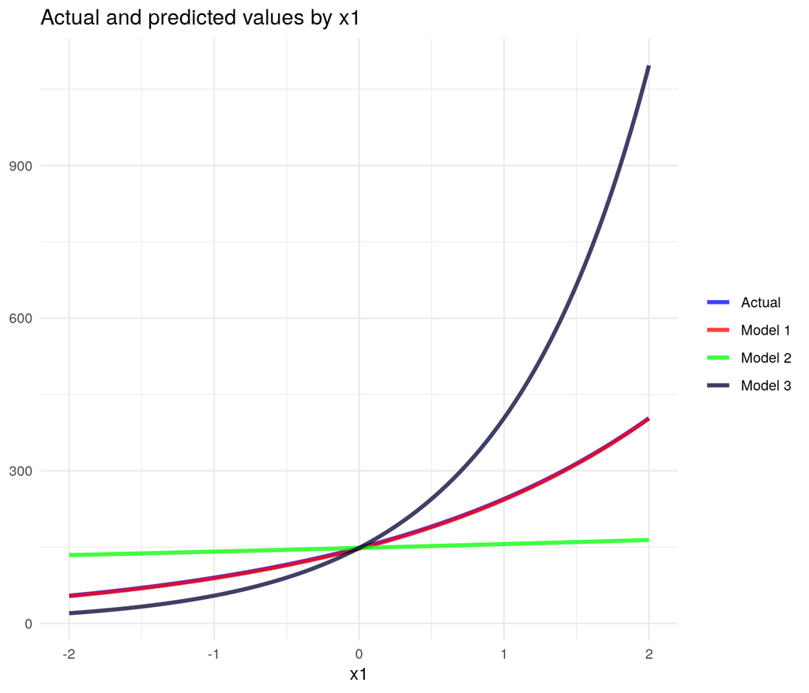

```r
data_sim_compare <- tibble(
  x1 = seq(-2, 2, by = 0.01),
  `Model 1` = exp(coef(fitted_model_1)[1] + coef(fitted_model_1)[2] * x1),
  `Model 2` = exp(5 + 0.05 * x1),
  `Model 3` = exp(5 + x1),
  Actual = exp(5 + 0.5 * x1)
) %>%
  tidyr::pivot_longer(
    c(starts_with("Model"), Actual),
    names_to = "model",
    values_to = "value"
  )

ggplot(data = data_sim_compare) +
  theme_minimal() +
  geom_line(
    aes(x = x1, y = value, color = model),
    size = 1.2,
    alpha = 0.75
  ) +
  scale_color_manual(values = pals::glasbey(4)) +
  theme(
    legend.title = element_blank(),
    axis.title.y = element_blank()
  ) +
  ggtitle("Actual and predicted values by x1")
```

Let’s see the Lorenz curves for these three sets of predictions. As in the simple example, the three sets of predictions all have the same rank ordering of predicted values, so their Lorenz curves are identical.

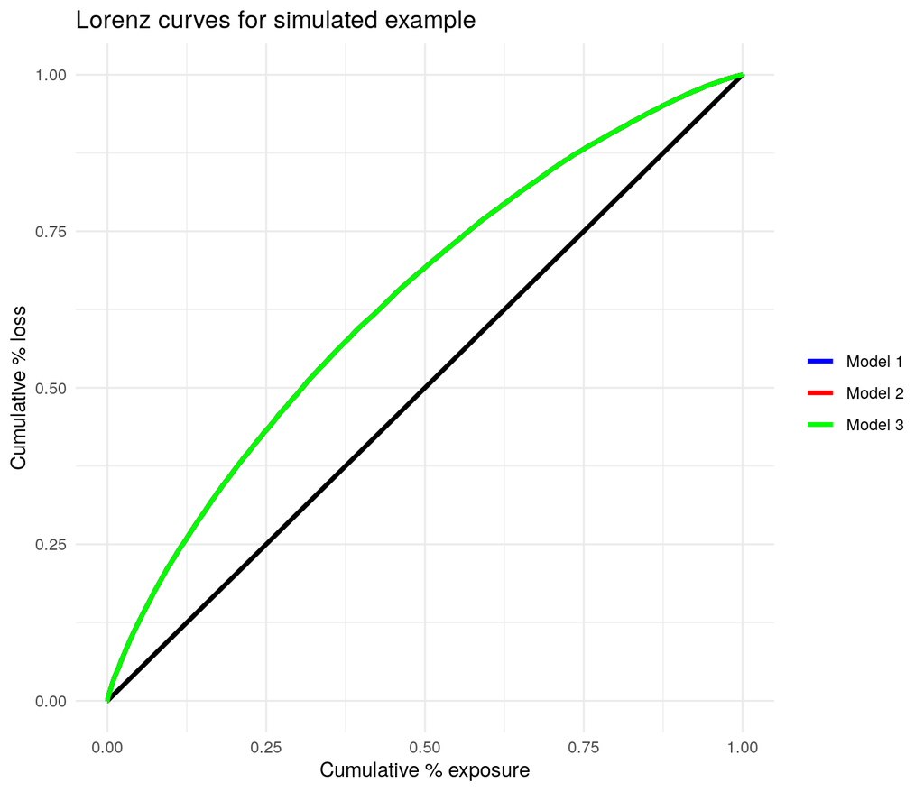

```r
sim_lorenz_1 <- calc_lorenz_curve(data_sim_pred_compare, "predict_1", "loss", "weight")
sim_lorenz_2 <- calc_lorenz_curve(data_sim_pred_compare, "predict_2", "loss", "weight")
sim_lorenz_3 <- calc_lorenz_curve(data_sim_pred_compare, "predict_3", "loss", "weight")

sim_lorenz <- bind_rows(
  sim_lorenz_1 %>%
    as_tibble() %>%
    mutate(model = "Model 1"),
  sim_lorenz_2 %>%
    as_tibble() %>%
    mutate(model = "Model 2"),
  sim_lorenz_3 %>%
    as_tibble() %>%
    mutate(model = "Model 3")
)

plot_dist_curve(
  sim_lorenz,
  "cum_pct_tgt",
  "cum_pct_wgt",
  "model",
  title = "Lorenz curves for simulated example"
) +
  xlab("Cumulative % exposure") +
  ylab("Cumulative % loss")
```

Now let’s look at the distribution comparison curves for these three predictions.

We see that the curve for Model 1, which fit well, is almost entirely on top of the 45-degree line of equality.

The curve Model 2, which had too flat of a slope (overpredicting for lower loss and underpredicting for higher loss) lies below the line of equality, while the curve for Model 3, which had too steep of a slope (underpredicting for lower loss and overpredicting for higher loss) lies above the line of equality.

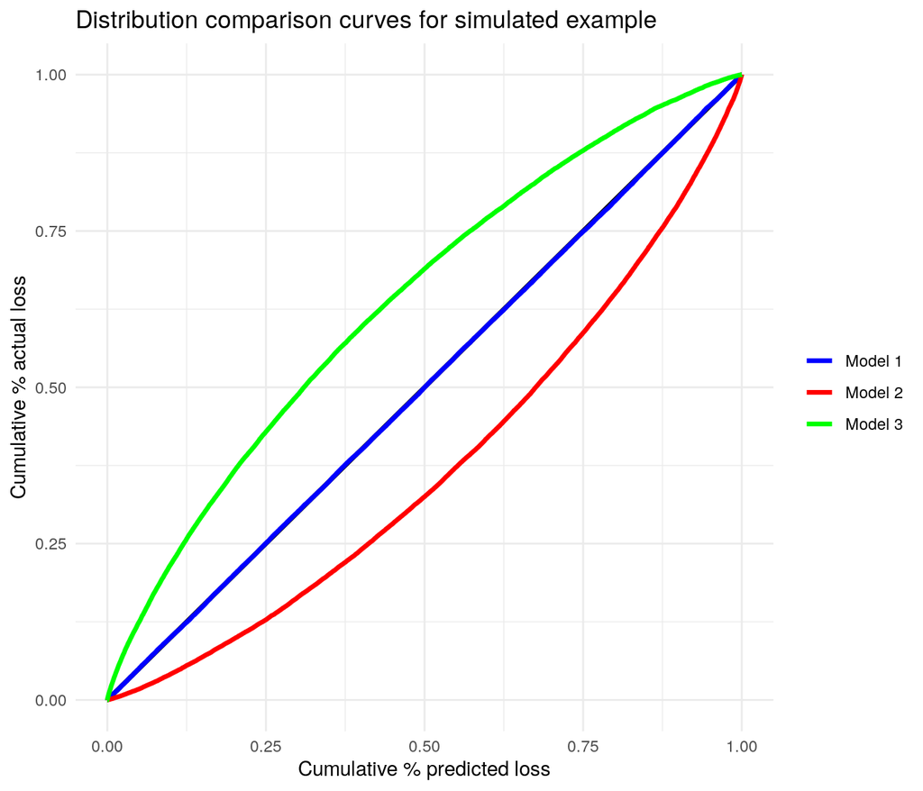

```r
sim_dist_curve_1 <- calc_prem_dist_curve(data_sim_pred_compare, "predict_1", "loss", "weight")
sim_dist_curve_2 <- calc_prem_dist_curve(data_sim_pred_compare, "predict_2", "loss", "weight")
sim_dist_curve_3 <- calc_prem_dist_curve(data_sim_pred_compare, "predict_3", "loss", "weight")

sim_dist_curve <- bind_rows(
  sim_dist_curve_1 %>%
    as_tibble() %>%
    mutate(model = "Model 1"),
  sim_dist_curve_2 %>%
    as_tibble() %>%
    mutate(model = "Model 2"),
  sim_dist_curve_3 %>%
    as_tibble() %>%
    mutate(model = "Model 3")
)

plot_dist_curve(
  sim_dist_curve,
  tgt_col = "cum_pct_tgt",
  wgt_col = "cum_pct_pred",
  "model",
  title = "Distribution comparison curves for simulated example"
) +
  xlab("Cumulative % predicted loss") +
  ylab("Cumulative % actual loss")
```

Let’s calculate the Cramer-von Mises statistic for these predictions.

We see that Model 1 has the lowest Cramer-von Mises statistic, indicating the best fit between predicted and actual losses.

```r
calc_prem_cvm(sim_dist_curve_1)
```

```
## [1] 7.493846e-07
```

```r
calc_prem_cvm(sim_dist_curve_2)
```

```
## [1] 0.01843143
```

```r
calc_prem_cvm(sim_dist_curve_3)
```

```
## [1] 0.02178135
```

## 4.4 Limitation/pitfall of distribution curves

There is an important limitation/pitfall to keep in mind when using this type of distribution curve.

If the predicted values are completely random and have no relationship to the actual values, the distribution comparison curve will generally hug very close to the line of equality!

For example, let’s create another prediction for the simulated Tweedie example, where this is just a random draw from a scaled uniform distribution.

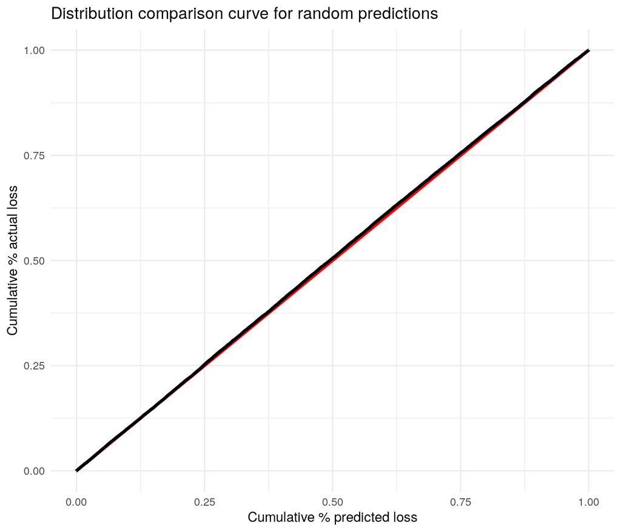

```r
data_sim_pred_random <- data_sim_pred_compare %>%
  mutate(predict_random = runif(n(), min = 165, max = 170))

dist_curve_random <- calc_prem_dist_curve(
  data_sim_pred_random,
  "predict_random",
  "loss",
  "weight"
)

plot_dist_curve(
  dist_curve_random,
  "cum_pct_tgt",
  "cum_pct_pred",
  title = "Distribution comparison curve for random predictions"
) +
  xlab("Cumulative % predicted loss") +
  ylab("Cumulative % actual loss")
```

We see that the curve lies almost very close to the line of equality.

Calculating the Cramer-von Mises distance, we get a very small value.

```r
calc_prem_cvm(dist_curve_random)
```

```
## [1] 1.807999e-05
```

However, this situation can be identified through the Lorenz curve.

We see the Lorenz curve virtually on top of the line of equality and an area under the curve of around 0.5, indicating zero value to this set of predictions.

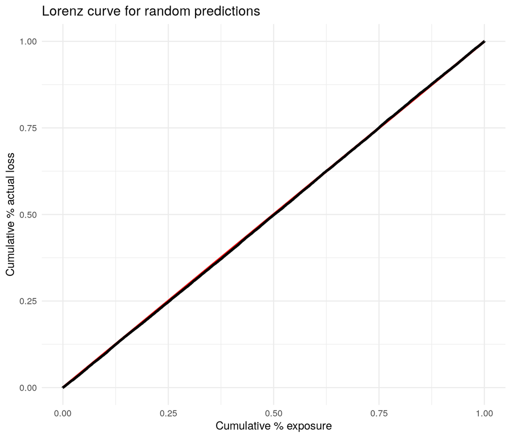

```r
lorenz_curve_random <- calc_lorenz_curve(
  data_sim_pred_random,
  "predict_random",
  "loss",
  "weight"
)

plot_dist_curve(
  lorenz_curve_random,
  "cum_pct_tgt",
  "cum_pct_wgt",
  title = "Lorenz curve for random predictions"
) +
  xlab("Cumulative % exposure") +
  ylab("Cumulative % actual loss")
```

```r
calc_lorenz_auc(lorenz_curve_random)
```

```
## [1] 0.498878
```

## 4.5 Revisiting simple example

Let’s return to the simple example we looked at at the end of the Lorenz curve section.

We see the curve for Model 2, which was the best fit to actual, is close to the line of equality. By comparison, the curve for Model 1, which is too flat (overpredicting lower loss and underpredicting higher loss), is below the line of equality, while the curve for Model 3, which is too steep (underpredicting lower loss and overpredicting higher loss) is above the line of equality, the same relationship we saw in the case of the simulated data example.

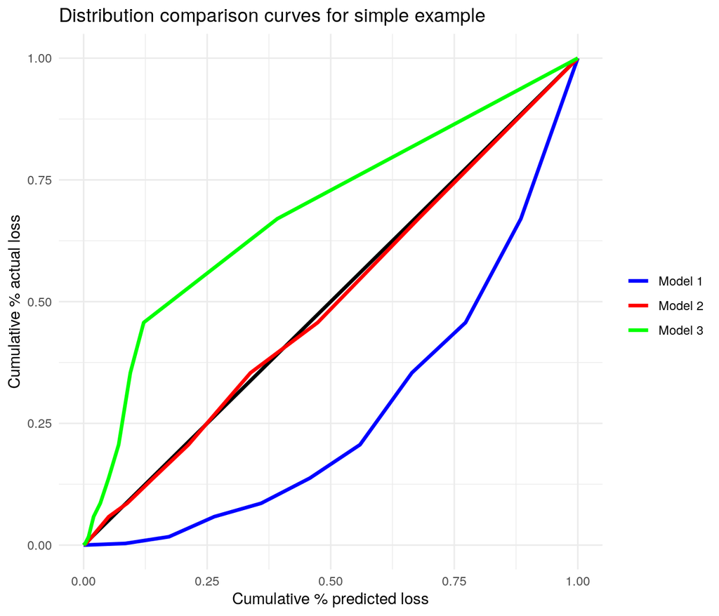

```r
simple_dist_1 <- calc_prem_dist_curve(simple_example, "predict_1", "actual_loss", "weight")
simple_dist_2 <- calc_prem_dist_curve(simple_example, "predict_2", "actual_loss", "weight")
simple_dist_3 <- calc_prem_dist_curve(simple_example, "predict_3", "actual_loss", "weight")

simple_dist <- bind_rows(
  simple_dist_1 %>%
    as_tibble() %>%
    mutate(model = "Model 1"),
  simple_dist_2 %>%
    as_tibble() %>%
    mutate(model = "Model 2"),
  simple_dist_3 %>%
    as_tibble() %>%
    mutate(model = "Model 3")
)

plot_dist_curve(
  simple_dist,
  "cum_pct_tgt",
  "cum_pct_pred",
  "model",
  title = "Distribution comparison curves for simple example"
) +
  xlab("Cumulative % predicted loss") +
  ylab("Cumulative % actual loss")
```

# 5 Variance of predictions

One last metric we used in the regularization model fitting notebook was the weighted variance of predicted values. The variance of predictions can be used as a measure of the amount of segmentation produced by a model. The greater the variance, the greater the amount of segmentation.

The combination of Lorenz curves and distribution comparison curves is probably sufficient for model comparison and evaluation.

One wants to have the maximum amount of directional segmentation as measured in a Lorenz curve as well as a distribution of predicted loss that is well-calibrated to the distribution of actual loss. Setting the optimization of those two criteria in place, the variance of predictions will be boxed in at whatever the model optimizing those two metrics produces.

Thus for optimization, just considering the combination of Lorenz curve and distribution comparison curve probably suffices.

However, it can still be useful or interesting to check the variance of predictions to get an idea of the amount of segmentation. If one is interested in assessing or quantifying the segmentation provided by a set of factors, the variance of predictions is a better way to quantify that than other metrics. See the document on interpreting factor relativities, which has a discussion on metrics for quantifying segmentation.

# 6 Analogy to decile lift charts

There is a natural analogy between the distribution distance and prediction variance metrics and some metrics calculated off of a decile lift chart. The distribution distance and prediction variance can be seen as continuous version analogues of their decile lift chart analogues.

The following expandable chunk has code for creating lift charts, plotting lift charts, and computing metrics on lift charts.

```r
label_n_tile <- function(n_tiles) {
  dplyr::recode(
    as.character(n_tiles),
    "3" = "tertile",
    "4" = "quartile",
    "5" = "quintile",
    "6" = "sextile",
    "7" = "septile",
    "8" = "octile",
    "10" = "decile",
    "12" = "duodecile",
    "16" = "hexadecile",
    "20" = "ventile",
    "100" = "percentile",
    .default = paste0(n_tiles, "-quantile")
  )
}

create_lift_chart <- function(data,
                              pred_col,
                              tgt_col,
                              wgt_col,
                              n_tiles = 10) {
  wgt_col <- sym(wgt_col)
  tgt_col <- sym(tgt_col)
  pred_col <- sym(pred_col)
  data_agg <- data %>%
    dtplyr::lazy_dt() %>%
    arrange(!!pred_col) %>%
    mutate(.cum_pct_wgt = cumsum(!!wgt_col) / sum(!!wgt_col)) %>%
    group_by(.n_tile = ceiling(n_tiles * .cum_pct_wgt)) %>%
    summarise(
      Predicted = sum(!!pred_col * !!wgt_col),
      Actual = sum(!!tgt_col * !!wgt_col)
    ) %>%
    as_tibble()
  data_agg %>%
    tidyr::pivot_longer(c(Predicted, Actual), names_to = "type") %>%
    mutate(type = factor(type, levels = c("Predicted", "Actual"))) %>%
    rename(n_tile = .n_tile)
}

calc_lift_stats <- function(lift_chart) {
  lift_chart %>%
    tidyr::pivot_wider(names_from = type, values_from = value) %>%
    arrange(n_tile) %>%
    summarise(
      n_tile_mape = yardstick::mape_vec(Predicted, Actual),
      n_tile_ratio = dplyr::last(Actual) / dplyr::first(Actual)
    )
}

plot_lift_chart <- function(lift_data,
                            title_label,
                            tgt_label,
                            wgt_label) {
  n_tile_label <- label_n_tile(max(lift_data[["n_tile"]]))
  ggplot(data = lift_data) +
    theme_minimal() +
    geom_bar(
      aes(x = n_tile, y = value, fill = type),
      stat = "identity",
      position = "dodge"
    ) +
    scale_x_continuous(stringr::str_to_title(n_tile_label), breaks = 1:10) +
    scale_y_continuous(tgt_label, labels = scales::comma) +
    theme(legend.title = element_blank()) +
    ggtitle(
      glue::glue("Actual vs predicted by {n_tile_label} - {title_label}"),
      subtitle = glue::glue("Equal {wgt_label} in each {n_tile_label}")
    )
}
```

Let’s create a lift chart for the first simulated example.

```r
sim_decile_lift <- create_lift_chart(
  data_sim_pred_1,
  "predict",
  "loss",
  "weight"
)
```

The `plot_lift_chart` function can be used to plot lift charts.

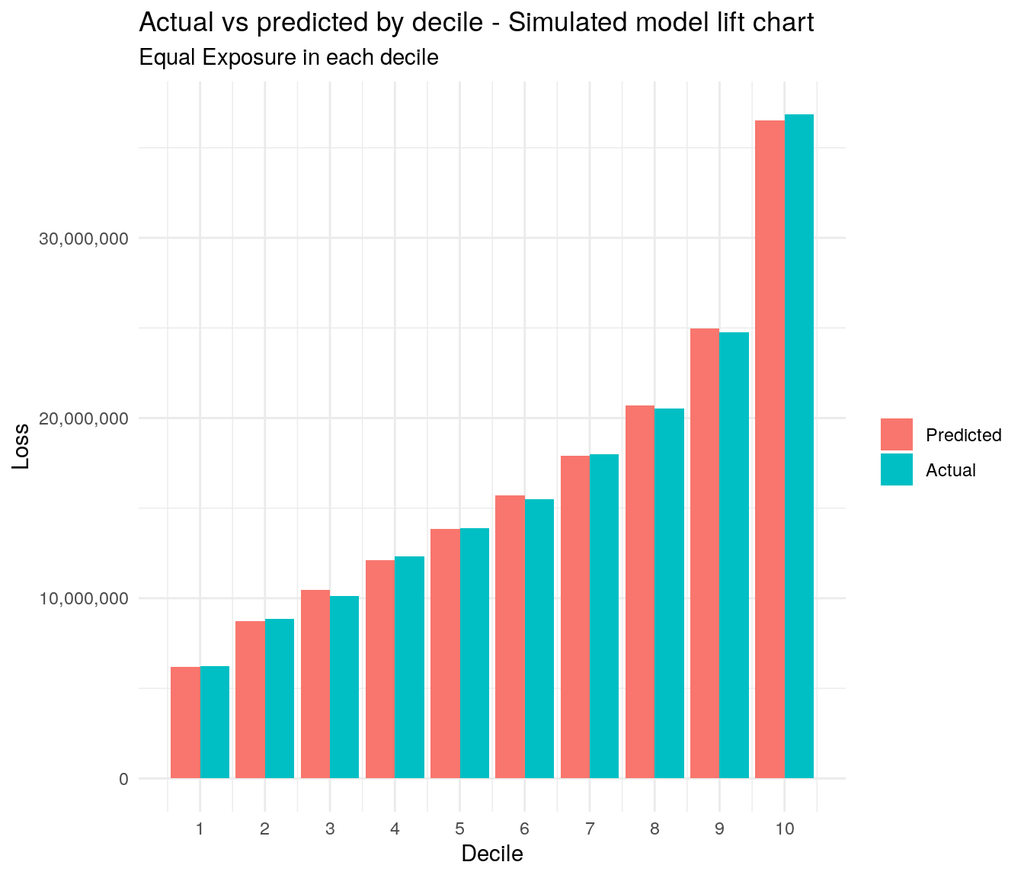

```r
plot_lift_chart(
  sim_decile_lift,
  "Simulated model lift chart",
  "Loss",
  "Exposure"
)
```

The `calc_lift_stats` function will calculate two metrics from the lift chart: the MAPE across the deciles and the ratio between the high and low deciles.

```r
calc_lift_stats(sim_decile_lift)
```

```
## # A tibble: 1 x 2
##   n_tile_mape n_tile_ratio
##         <dbl>        <dbl>
## 1        1.18         5.92
```

The MAPE of bins in a lift chart can be seen as being like the distribution distance metric.

We are getting a quantiative measure of the fit of the predicted values to the actual distribution, in terms of how closely the predicted loss dollars match the actual loss dollars in a decile.

Like the distribution distance metric, decile lift chart MAPE suffers from the same pitfall when it comes to random predictions.

Let’s plot decile lift charts for the four sets of predicted values on the first simulated example.

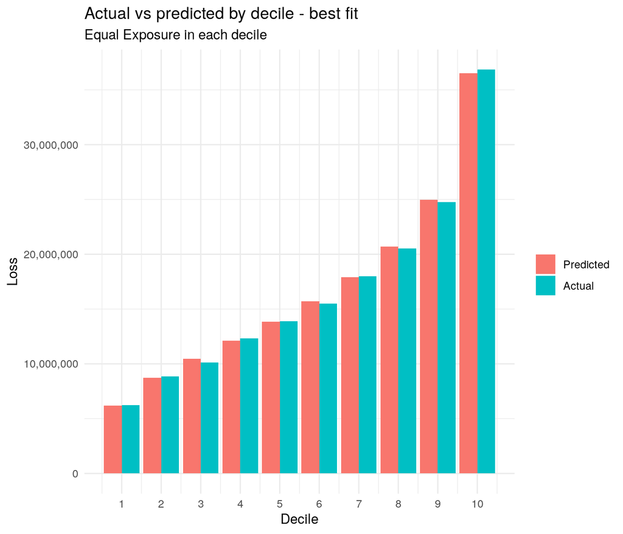

```r
decile_lift_1 <- create_lift_chart(
  data_sim_pred_random,
  "predict_1",
  "loss",
  "weight"
)

decile_lift_2 <- create_lift_chart(
  data_sim_pred_random,
  "predict_2",
  "loss",
  "weight"
)

decile_lift_3 <- create_lift_chart(
  data_sim_pred_random,
  "predict_3",
  "loss",
  "weight"
)

decile_lift_4 <- create_lift_chart(
  data_sim_pred_random,
  "predict_random",
  "loss",
  "weight"
)

plot_lift_chart(
  decile_lift_1,
  "best fit",
  "Loss",
  "Exposure"
)
```

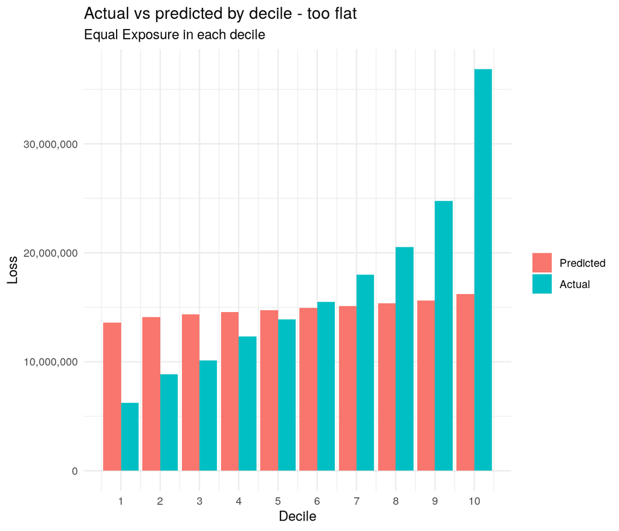

```r
plot_lift_chart(
  decile_lift_2,
  "too flat",
  "Loss",
  "Exposure"
)
```

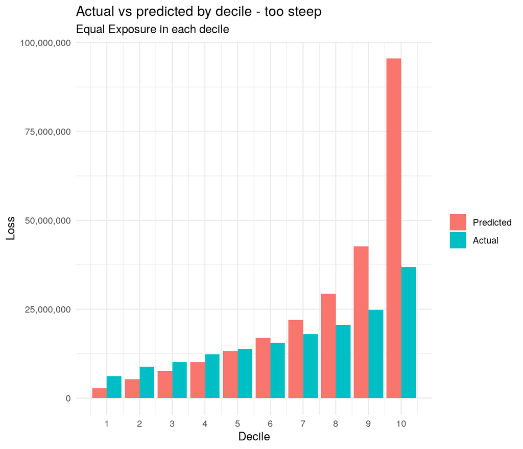

```r
plot_lift_chart(
  decile_lift_3,
  "too steep",
  "Loss",
  "Exposure"
)
```

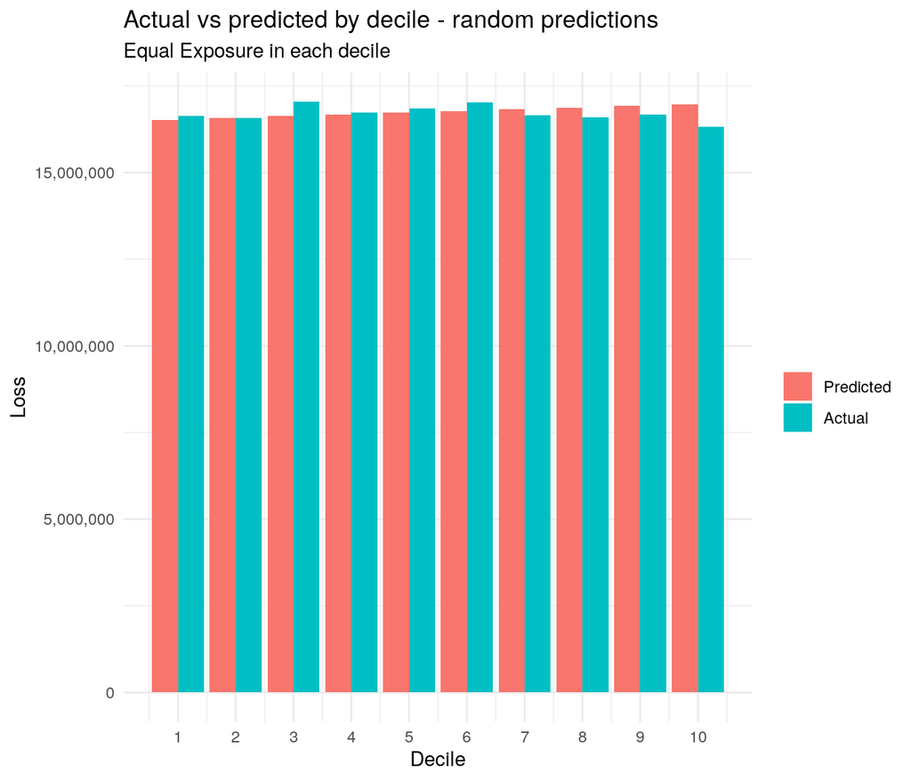

```r
plot_lift_chart(
  decile_lift_4,
  "random predictions",
  "Loss",
  "Exposure"
)
```

Let’s calculate the lift metrics for each of the four sets of predictions.

```r
calc_lift_stats(decile_lift_1)
```

```
## # A tibble: 1 x 2
##   n_tile_mape n_tile_ratio
##         <dbl>        <dbl>
## 1        1.18         5.92
```

```r
calc_lift_stats(decile_lift_2)
```

```
## # A tibble: 1 x 2
##   n_tile_mape n_tile_ratio
##         <dbl>        <dbl>
## 1        38.4         5.92
```

```r
calc_lift_stats(decile_lift_3)
```

```
## # A tibble: 1 x 2
##   n_tile_mape n_tile_ratio
##         <dbl>        <dbl>
## 1        41.5         5.92
```

```r
calc_lift_stats(decile_lift_4)
```

```
## # A tibble: 1 x 2
##   n_tile_mape n_tile_ratio
##         <dbl>        <dbl>
## 1        1.36        0.981
```

We see that the random predictions had very low MAPE, similar to that of the fitted model predictions. This is just like the low distribution distance of random predictions for the distribution distance curve.

The high/low decile ratio can be seen as a decile lift chart analogue of the variance of predictions. A higher high/low decile ratio indicates a greater range of segmentation.

The advantage of the distribution difference curve and variance of predictions as measures (along with the Lorenz curve) is that they operate on the full distribution without introducing some of the artificiality and loss of information that can result from discretization. Furthermore, these metrics can be interpreted as being like continuous versions of metrics computed off of decile lift charts, perhaps making it easier for someone familiar with decile lift charts to readily understand.